# Employee Attrition Prediction with R Accelerator

Le Zhang, Data Scientist at Microsoft  
2017-03-09

### Agenda

- Introduction.
- How to predict employee attrition?
- Walk-through of an R “accelerator”.

### Introduction

- Microsoft Algorithms and Data Science (ADS).

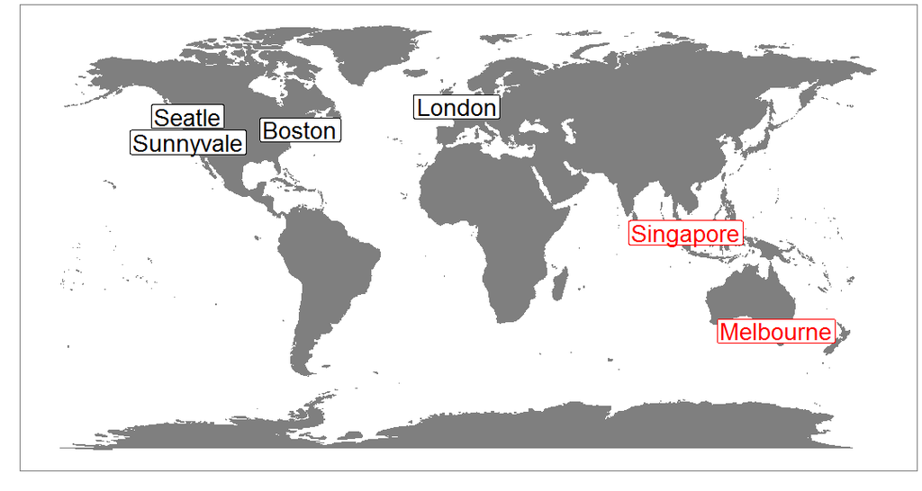

- ADS Asia Pacific.
  - Data science solution templates to resolve real-world problems.
  - Scalable tools & algorithms for high performance advanced analytics.

### Data science and machine learning

- Data science & Machine learning
- A review on iris data.

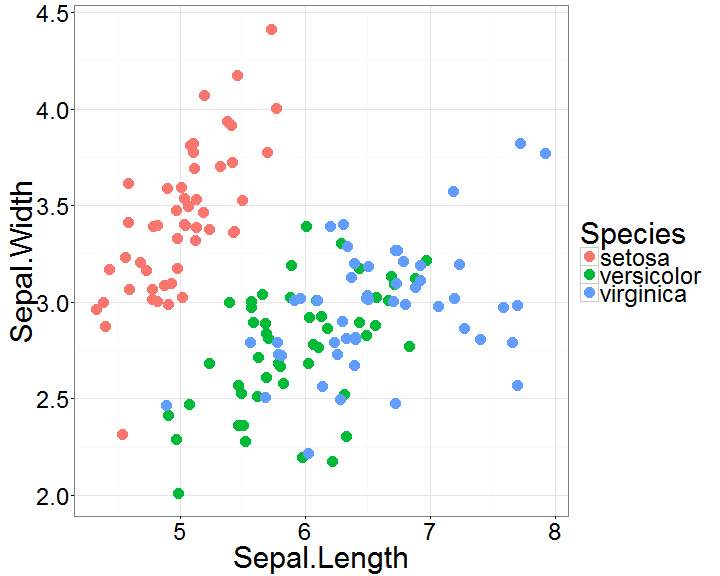

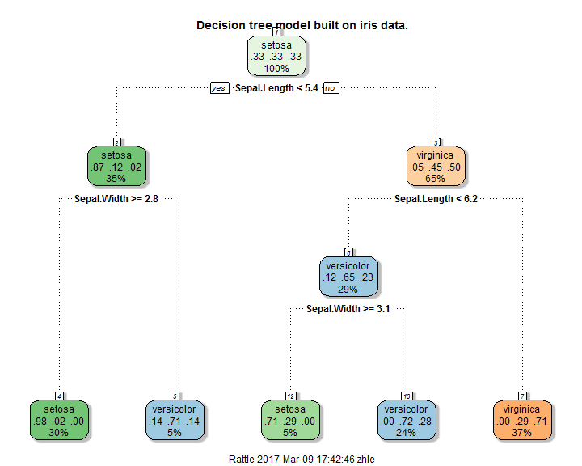

- Is that all?

### Real-world data science project

- Team Data Science Process (TDSP) https://github.com/Azure/Microsoft-TDSP.
  - Collaborative.
  - Iterative.

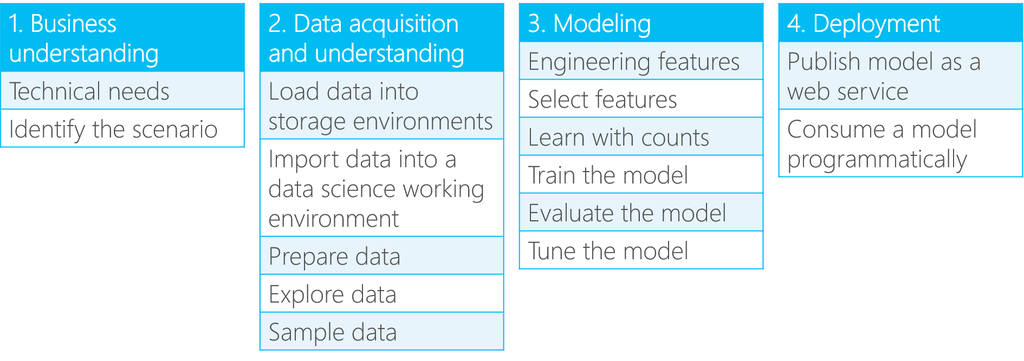

### Use case - employee attrition prediction

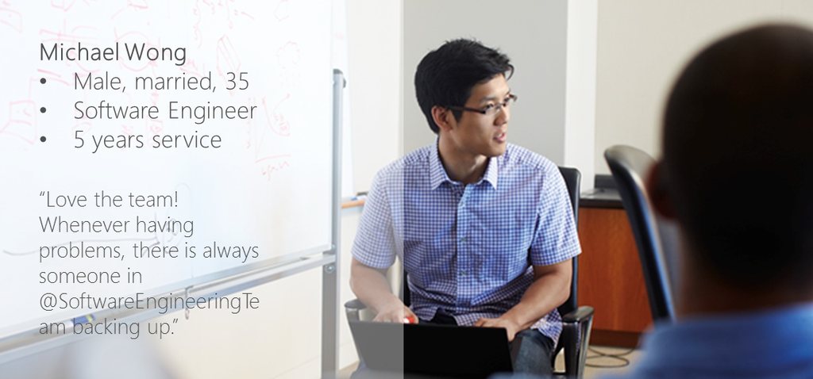

- Consequences of employee attrition.
  - Loss of human resources and cost on new hires.
  - Potential loss of company intellectual properties.
- Problem formalization: **to identify employees with inclination of leaving.**

### Data collection, exploration, and preparation

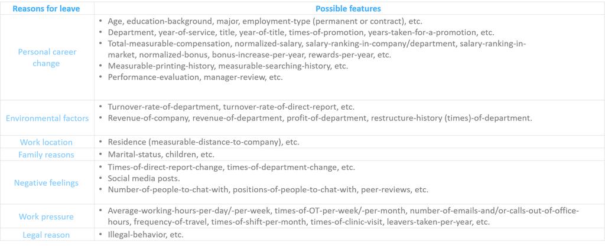

- Static data: not change or change in a deterministic manner.
- Dynamic data: change randomly over time.

### Data collection, exploration, and preparation (Cont'd)

- Data source
  - HR department.
  - IT department.
  - Direct reports.
  - Social media network.

### Data collection, exploration, and preparation (Cont'd)

- Data exploration.
  - Statistical analysis.
  - Visualization!

### Data collection, exploration, and preparation (Cont'd)

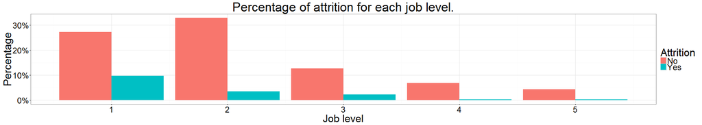

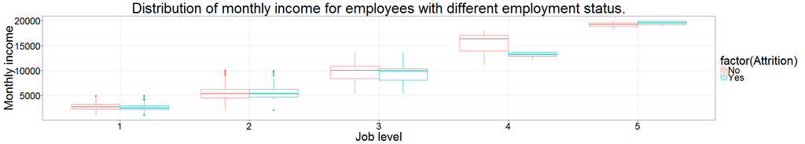

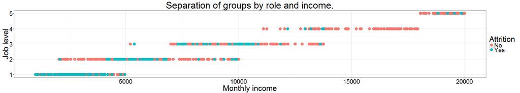

### Data collection, exploration, and preparation (Cont'd)

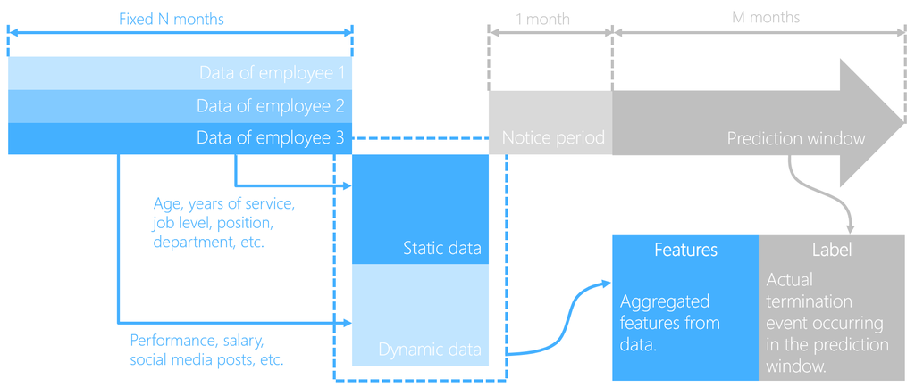

**To predict employee attrition in the next M + 1 months, by analyzing employee data of last N months.**

### Feature Extraction

- Feature engineering
  - Statistics
    - max, min, standard deviation, etc.
  - Time series characterization.
    - Trend analysis.
    - Anomaly detection.
    - Time series model (ARIMA, etc.)
  - Text mining
- Feature selection.
  - Correlation analysis.
  - Model based feature selection.

### Model creation and validation

- Supervised classification problem.
- Algorithm selection
  - Logistic regression, Support vector machine, Decision tree, etc.
  - Ensemble
    - Bagging.
    - Boosting.
    - Stacking.
- Model creation

### Model creation and validation

- Cross validation.
- Confusion matrix.
  - Precision.
  - Recall.
  - F Score.
  - Area-Under-Curve.

### Employee attrition prediction - R accelerator

- What is R “accelerator”
  - Lightweight end-to-end solution template.
  - Follows Microsoft Team Data Science Process (TDSP) format, in a simplified version.
  - Easy for prototyping, presenting, and documenting.
  - Github repo https://github.com/Microsoft/acceleratoRs

### Step 0 Setup

### Step 1 Data exploration

- Employee attrition data: https://www.ibm.com/communities/analytics/watson-analytics-blog/hr-employee-attrition/

```r
dim(df1)
```

```
[1] 1470   33
```

- Review comments data: http://www.glassdoor.com

```r
head(df2$Feedback, 3)
```

```
[1] "People are willing to share knowledge which is not the norm in this industry This is the first place I have worked where the people are great about that Also I get to work on cool projects that no one else in the world works on"
[2] "To repeat what I wrote before the people I work for and work with here are very smart and confident people"
[3] "The variety of different projects and the speed of completion I am truly very satisfied  pleased there is an endless list of pros"
```